# Instructions

1. import NYC_Accidents_2020.csv as a DataFrame
- bring in the csv file by using read_csv from pandas; don't use any keyword arguments initially
- use a relative path as if your notebook were opened from the root of the repository if possible (../data/raw/NYC_Accidents_2020.csv)
- compare the resulting DataFrame against opening the spreadsheet in LibreOffice, Google Sheets, Excel, Numbers, etc.
- you should immediately see an issue with the import
- use a keyword argument from the docs to fix the issue
- in a markdown cell after the import, describe what fix had to be made to make the initial import usable

```python
import sys
import pandas as pd
```

The first three rows of the file are general descriptions about the dataset. We hava to skip the first three rows when reading the csv to ensure that the dataset has the right column names.

```python
file_path = sys.path[0] +'/../data/raw/NYC_Accidents_2020.csv'
accidents = pd.read_csv(file_path, skiprows=3)
```

1. display columns and row samples
- show only the names of the columns
- show the first 5 rows
- show a random sampling of 5 rows
- show the last 5 rows

```python
print(f'The names of the columns:\n {accidents.columns}')
```

```
The names of the columns:
 Index(['CRASH DATE', 'CRASH TIME', 'BOROUGH', 'ZIP CODE', 'LATITUDE',
       'LONGITUDE', 'LOCATION', 'ON STREET NAME', 'CROSS STREET NAME',
       'OFF STREET NAME', 'NUMBER OF PERSONS INJURED',
       'NUMBER OF PERSONS KILLED', 'NUMBER OF PEDESTRIANS INJURED',
       'NUMBER OF PEDESTRIANS KILLED', 'NUMBER OF CYCLIST INJURED',
       'NUMBER OF CYCLIST KILLED', 'NUMBER OF MOTORIST INJURED',
       'NUMBER OF MOTORIST KILLED', 'CONTRIBUTING FACTOR VEHICLE 1',
       'CONTRIBUTING FACTOR VEHICLE 2', 'CONTRIBUTING FACTOR VEHICLE 3',
       'CONTRIBUTING FACTOR VEHICLE 4', 'CONTRIBUTING FACTOR VEHICLE 5',
       'COLLISION_ID', 'VEHICLE TYPE CODE 1', 'VEHICLE TYPE CODE 2',
       'VEHICLE TYPE CODE 3', 'VEHICLE TYPE CODE 4', 'VEHICLE TYPE CODE 5'],
      dtype='object')
```

```python
accidents.head(5)
```

|  | CRASH DATE | CRASH TIME | BOROUGH | ZIP CODE | LATITUDE | LONGITUDE | LOCATION | ON STREET NAME | CROSS STREET NAME | OFF STREET NAME | ... | CONTRIBUTING FACTOR VEHICLE 2 | CONTRIBUTING FACTOR VEHICLE 3 | CONTRIBUTING FACTOR VEHICLE 4 | CONTRIBUTING FACTOR VEHICLE 5 | COLLISION_ID | VEHICLE TYPE CODE 1 | VEHICLE TYPE CODE 2 | VEHICLE TYPE CODE 3 | VEHICLE TYPE CODE 4 | VEHICLE TYPE CODE 5 |
| --- | --- | --- | --- | --- | --- | --- | --- | --- | --- | --- | --- | --- | --- | --- | --- | --- | --- | --- | --- | --- | --- |
| 0 | 8/29/20 | 15:40:00 | BRONX | 10466.0 | 40.89210 | -73.833760 | POINT (-73.83376 40.8921) | PRATT AVENUE | STRANG AVENUE | NaN | ... | Unspecified | NaN | NaN | NaN | 4342908 | Sedan | Station Wagon/Sport Utility Vehicle | NaN | NaN | NaN |
| 1 | 8/29/20 | 21:00:00 | BROOKLYN | 11221.0 | 40.69050 | -73.919914 | POINT (-73.919914 40.6905) | BUSHWICK AVENUE | PALMETTO STREET | NaN | ... | Unspecified | NaN | NaN | NaN | 4343555 | Sedan | Sedan | NaN | NaN | NaN |
| 2 | 8/29/20 | 18:20:00 | NaN | NaN | 40.81650 | -73.946556 | POINT (-73.946556 40.8165) | 8 AVENUE | NaN | NaN | ... | NaN | NaN | NaN | NaN | 4343142 | Station Wagon/Sport Utility Vehicle | NaN | NaN | NaN | NaN |
| 3 | 8/29/20 | 0:00:00 | BRONX | 10459.0 | 40.82472 | -73.892960 | POINT (-73.89296 40.82472) | NaN | NaN | 1047 SIMPSON STREET | ... | Unspecified | Unspecified | Unspecified | NaN | 4343588 | Station Wagon/Sport Utility Vehicle | Station Wagon/Sport Utility Vehicle | Sedan | Motorcycle | NaN |
| 4 | 8/29/20 | 17:10:00 | BROOKLYN | 11203.0 | 40.64989 | -73.933890 | POINT (-73.93389 40.64989) | NaN | NaN | 4609 SNYDER AVENUE | ... | Unspecified | NaN | NaN | NaN | 4342953 | Sedan | Sedan | NaN | NaN | NaN |

5 rows × 29 columns

```python
accidents.sample(5)
```

|  | CRASH DATE | CRASH TIME | BOROUGH | ZIP CODE | LATITUDE | LONGITUDE | LOCATION | ON STREET NAME | CROSS STREET NAME | OFF STREET NAME | ... | CONTRIBUTING FACTOR VEHICLE 2 | CONTRIBUTING FACTOR VEHICLE 3 | CONTRIBUTING FACTOR VEHICLE 4 | CONTRIBUTING FACTOR VEHICLE 5 | COLLISION_ID | VEHICLE TYPE CODE 1 | VEHICLE TYPE CODE 2 | VEHICLE TYPE CODE 3 | VEHICLE TYPE CODE 4 | VEHICLE TYPE CODE 5 |
| --- | --- | --- | --- | --- | --- | --- | --- | --- | --- | --- | --- | --- | --- | --- | --- | --- | --- | --- | --- | --- | --- |
| 13646 | 7/16/20 | 11:02:00 | QUEENS | 11422.0 | 40.658768 | -73.73768 | POINT (-73.73768 40.658768) | 249 STREET | 145 AVENUE | NaN | ... | Unspecified | NaN | NaN | NaN | 4329281 | Station Wagon/Sport Utility Vehicle | Sedan | NaN | NaN | NaN |
| 69635 | 1/13/20 | 17:33:00 | QUEENS | 11413.0 | 40.682404 | -73.75181 | POINT (-73.75181 40.682404) | LUCAS STREET | SPRINGFIELD BOULEVARD | NaN | ... | Unspecified | NaN | NaN | NaN | 4272811 | Pick-up Truck | Sedan | NaN | NaN | NaN |
| 22319 | 6/14/20 | 19:50:00 | NaN | NaN | 40.697330 | -73.78456 | POINT (-73.78456 40.69733) | MERRICK BOULEVARD | NaN | NaN | ... | Unspecified | NaN | NaN | NaN | 4320336 | Sedan | Station Wagon/Sport Utility Vehicle | NaN | NaN | NaN |
| 46559 | 3/1/20 | 18:35:00 | MANHATTAN | 10036.0 | 40.758980 | -73.99595 | POINT (-73.99595 40.75898) | WEST 41 STREET | 10 AVENUE | NaN | ... | Unspecified | NaN | NaN | NaN | 4296400 | Station Wagon/Sport Utility Vehicle | Sedan | NaN | NaN | NaN |
| 55975 | 2/10/20 | 16:00:00 | QUEENS | 11419.0 | 40.685400 | -73.82947 | POINT (-73.82947 40.6854) | LIBERTY AVENUE | 113 STREET | NaN | ... | Unspecified | NaN | NaN | NaN | 4286752 | Sedan | Station Wagon/Sport Utility Vehicle | NaN | NaN | NaN |

5 rows × 29 columns

```python
accidents.tail(5)
```

|  | CRASH DATE | CRASH TIME | BOROUGH | ZIP CODE | LATITUDE | LONGITUDE | LOCATION | ON STREET NAME | CROSS STREET NAME | OFF STREET NAME | ... | CONTRIBUTING FACTOR VEHICLE 2 | CONTRIBUTING FACTOR VEHICLE 3 | CONTRIBUTING FACTOR VEHICLE 4 | CONTRIBUTING FACTOR VEHICLE 5 | COLLISION_ID | VEHICLE TYPE CODE 1 | VEHICLE TYPE CODE 2 | VEHICLE TYPE CODE 3 | VEHICLE TYPE CODE 4 | VEHICLE TYPE CODE 5 |
| --- | --- | --- | --- | --- | --- | --- | --- | --- | --- | --- | --- | --- | --- | --- | --- | --- | --- | --- | --- | --- | --- |
| 74876 | 1/1/20 | 15:13:00 | BRONX | 10459.0 | 40.826810 | -73.896510 | POINT (-73.89651 40.82681) | NaN | NaN | 1122 INTERVALE AVENUE | ... | NaN | NaN | NaN | NaN | 4268088 | Sedan | NaN | NaN | NaN | NaN |
| 74877 | 1/1/20 | 8:00:00 | BROOKLYN | 11235.0 | 40.582935 | -73.959210 | POINT (-73.95921 40.582935) | NaN | NaN | 3401 GUIDER AVENUE | ... | Unspecified | Unspecified | NaN | NaN | 4267756 | Station Wagon/Sport Utility Vehicle | Station Wagon/Sport Utility Vehicle | Station Wagon/Sport Utility Vehicle | NaN | NaN |
| 74878 | 1/1/20 | 11:36:00 | BRONX | 10461.0 | 40.848553 | -73.830055 | POINT (-73.830055 40.848553) | NaN | NaN | 1810 MAHAN AVENUE | ... | Unspecified | NaN | NaN | NaN | 4269230 | Sedan | Pick-up Truck | NaN | NaN | NaN |
| 74879 | 1/1/20 | 1:45:00 | MANHATTAN | 10017.0 | 40.753624 | -73.969440 | POINT (-73.96944 40.753624) | EAST 48 STREET | 2 AVENUE | NaN | ... | Driver Inattention/Distraction | NaN | NaN | NaN | 4267482 | Sedan | Taxi | NaN | NaN | NaN |
| 74880 | 1/1/20 | 18:00:00 | QUEENS | 11367.0 | 40.726875 | -73.830960 | POINT (-73.83096 40.726875) | NaN | NaN | 70-25 PARK DRIVE EAST | ... | Driver Inattention/Distraction | NaN | NaN | NaN | 4268376 | Sedan | Station Wagon/Sport Utility Vehicle | NaN | NaN | NaN |

5 rows × 29 columns

1. describe the rows and data types
- use any method to show:
  - each column
  - the type of each column
  - the number of non-missing values in each column
- in a markdown cell after displaying the column info:
  - list out the columns that look like they have the "wrong" (or too wide) type
  - and next to the column name, specify what type the column should probably be
  - lastly, preview the remainder of the instructions and write out any data transformations or cleaning that you think will be necessary to complete this part of the homework

```python
accidents.info()
```

```
<class 'pandas.core.frame.DataFrame'>
RangeIndex: 74881 entries, 0 to 74880
Data columns (total 29 columns):
 #   Column                         Non-Null Count  Dtype
---  ------                         --------------  -----
 0   CRASH DATE                     74881 non-null  object
 1   CRASH TIME                     74881 non-null  object
 2   BOROUGH                        49140 non-null  object
 3   ZIP CODE                       49134 non-null  float64
 4   LATITUDE                       68935 non-null  float64
 5   LONGITUDE                      68935 non-null  float64
 6   LOCATION                       68935 non-null  object
 7   ON STREET NAME                 55444 non-null  object
 8   CROSS STREET NAME              35681 non-null  object
 9   OFF STREET NAME                19437 non-null  object
```

[output cut: 21 more lines]

- columns that have too wide data type

  0 CRASH DATE date

  1 CRASH TIME date

  2 BOROUGH string

  3 ZIP CODE int

  6 LOCATION string

  7 ON STREET NAME string

  8 CROSS STREET NAME string

  9 OFF STREET NAME string

  18 CONTRIBUTING FACTOR VEHICLE 1 string

  19 CONTRIBUTING FACTOR VEHICLE 2 string

  20 CONTRIBUTING FACTOR VEHICLE 3 string

  21 CONTRIBUTING FACTOR VEHICLE 4 string

  22 CONTRIBUTING FACTOR VEHICLE 5 string

  24 VEHICLE TYPE CODE 1 string

  25 VEHICLE TYPE CODE 2 string

  26 VEHICLE TYPE CODE 3 string

  27 VEHICLE TYPE CODE 4 string

```python
accidents.drop(['LOCATION', 'COLLISION_ID'], axis = 1, inplace = True)
```

rename all columns from upper case to lower case for convenience

```python
accidents.columns = accidents.columns.map(lambda x: x.lower())
```

make all values in the borough column lower case for convenience.

```python
accidents.borough = accidents.borough.str.lower()
```

1. determine the top three streets(Use the ON STREET NAME column) that had the most accidents
- it's ok to show more than 3 streets
- show the street name and the number of accidents occurred on each street
- document every step that you use to do this, including how the data was cleaned and/or transformed

```python
print('Top three streets that had the most accidents:')
accidents['on street name'].value_counts()[:3]
```

```
Top three streets that had the most accidents:
```

```
BELT PARKWAY                  1241
LONG ISLAND EXPRESSWAY         745
BROOKLYN QUEENS EXPRESSWAY     738
Name: on street name, dtype: int64
```

1. shows the number of accidents that occurred at each borough
- show a visualization that allows comparison of the number of the accidents.
  - BRONX
  - BROOKLYN
  - QUEENS
  - MANHATTAN
  - everything else can fall under "other" (including missing values)
- document every step that you use to do this, including how the data was cleaned and/or transformed
- hint, read the accompanying data dictionary / glossary

First I transformed all the values in borough column to lower case. Then I replace the nan value in this column with 'other'. After that I used the value_counts() function to obtain the number of accidents in each borough. Finally, I made a bar plot of the accident distribution with respect to different borough in NYC.

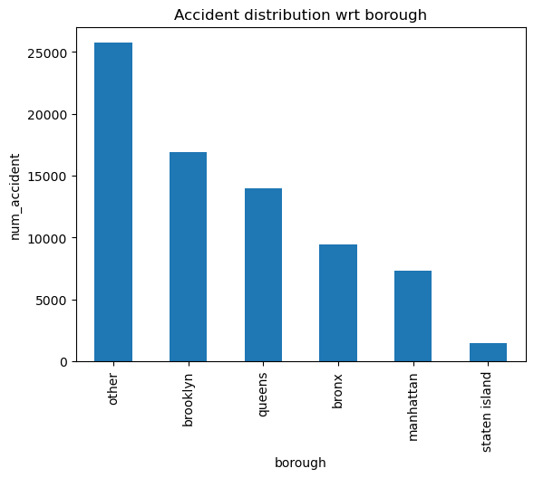

```python
import numpy as np
import matplotlib.pyplot as plt
accidents.borough.fillna('other').value_counts().plot.bar()
plt.title('Accident distribution wrt borough')
plt.xlabel('borough')
plt.ylabel('num_accident')
```

1. calculate summary statistics for the number of persons injured in all NYC and for a couple of selected boroughs (you can choose the two boroughs)
- use any method to calculate mean, median, percentiles (25 and 75), max, and min
- again, pick two boroughs
  - calculate summary statistics for each borough: use any method to calculate mean, median, percentiles (25 and 75), max, and min
  - in a markdown cell below the calculations, compare the results
- document every step that you use to do this, including how the data was cleaned and/or transformed

I first filter out accidents that occur in brooklyn, and then get their "number of persons injured" column valuesas a series. Then I compute the mean, median, 25 percentile, 75 percentile, min value and max value of the series.

Similarly, I first filter out accidents that occur in queens, and then get their "number of persons injured" column valuesas a series. Then I compute the mean, median, 25 percentile, 75 percentile, min value and max value of the series.

```python
num_injured_brooklyn = accidents[accidents['borough'] == 'brooklyn']['number of persons injured']
num_injured_queens = accidents[accidents['borough'] == 'queens']['number of persons injured']
print(f'Number of persons injured in an accident in Brooklyn \n \
    mean: {np.mean(num_injured_brooklyn)},\n \
    median: {np.median(num_injured_brooklyn)},\n \
    25 percentile: {np.percentile(num_injured_brooklyn, 25)},\n \
    75 percentile: {np.percentile(num_injured_brooklyn, 75)},\n \
    max: {np.max(num_injured_brooklyn)}, \n \
    min: {np.min(num_injured_brooklyn)}')

print(f'Number of persons injured in an accident in Queens \n \
    mean: {np.mean(num_injured_queens)},\n \
    median: {np.median(num_injured_queens)},\n \
    25 percentile: {np.percentile(num_injured_queens, 25)},\n \
    75 percentile: {np.percentile(num_injured_queens, 75)},\n \
    max: {np.max(num_injured_queens)}, \n \
    min: {np.min(num_injured_queens)}')
```

```
Number of persons injured in an accident in Brooklyn
     mean: 0.35630212338084816,
     median: 0.0,
     25 percentile: 0.0,
     75 percentile: 1.0,
     max: 15,
     min: 0
Number of persons injured in an accident in Queens
     mean: 0.32817293286723265,
     median: 0.0,
     25 percentile: 0.0,
     75 percentile: 1.0,
     max: 7,
     min: 0
```

Compare two results: The average number of persons injured in an accident in Brooklyn(0.35630) is slightly higher than that in Queens (0.32817). There is a maximum of 15 persons injured in an accident in Brroklyn, while the maximum number of persons injured in accidents occurred in Queens is 7. The 25 percentile, median, 75 percentile, and min value for the number of persons injured in an accident is the same for Brooklyns and Queens.

1. what are the distributions of accidents based on the geo location (latitude & longitude)?
- show a visualization that shows the accidents that occurred at each borough.
- that is plot the accidents based on the geo location, where x-axis is the latitude & y-axis is the longitude. And then differentiate the points by borough(by point color).
- document every step that you use to do this, including how the data was cleaned and/or transformed

For each borough, I filter out accidents that occurred in this borough and obtain its latitude and longitude series. I then plot a scatter plot using one color. Then I switch to another boroughs, follow the same procedure but plot with another color. The process is repeated five times until I finish looping over all boroughs. Note that when I plot the scatter plot, I restrict the x range from 40.25 to 41.25 and y range from -74.5 to -73.5 for clarity. zeros are dropped since it might have special meanings rather than representing the true data. I set alpha to 0.1 to reflect accident frequency in each location. Denser area has more number of accidents.

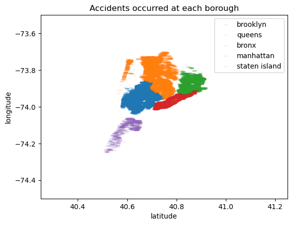

```python
colors = ['red', 'green', 'blue', 'purple', 'orange']
boroughs = list(accidents.borough.value_counts().index)
for i in range(len(boroughs)):
    latitude = accidents[accidents['borough'] == boroughs[i]].latitude
    longitude = accidents[accidents['borough'] == boroughs[i]].longitude
    plt.scatter(latitude, longitude, marker = 1, label = boroughs[i], alpha = 0.1)
    plt.xlim(40.25, 41.25)
    plt.ylim(-74.5, -73.5)
plt.legend()
plt.title("Accidents occurred at each borough")
plt.xlabel('latitude')
plt.ylabel('longitude')
plt.show()
```

1. shows the covariance between each pair of the columns
- choose the columns that you think are necessary & explain your choices
- document every step that you use to do this, including how the data was cleaned and/or transformed

I chose columns of numeric type in this dataset. I think the number of persons/pedestrians/cyclist/motorist injured/ killed should be correlated, because those numbers are likely all to be high in a serious accident, while being all low in a minor accident. .

I first select the columns that I believe should be correlated into a dataframe. Then I call .corr to calculate the correlation between each features. Then I visualize the correlation by plotting the correlation heatmap.

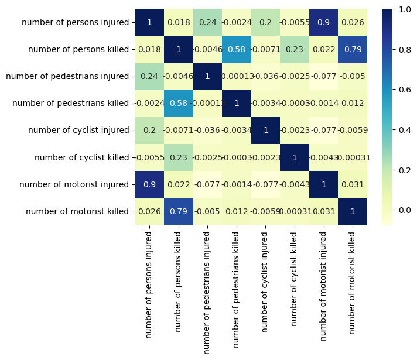

```python
import seaborn as sns
corr = accidents[['number of persons injured', 'number of persons killed',
       'number of pedestrians injured', 'number of pedestrians killed',
       'number of cyclist injured', 'number of cyclist killed',
       'number of motorist injured', 'number of motorist killed']].corr()
sns.heatmap(corr, annot=True, cmap="YlGnBu")
```

1. which month did the most number of accidents occur?
- document every step that you use to do this, including how the data was cleaned and/or transformed
- the calendar module and month_abbr may be useful for labels
- it's ok to show more than one month
- optionally, visualize this data instead of simply listing the counts
- in a markdown cell, what can you conclude about when accidents reach a lull?

I transform the column "crash date" to datetime type to obtain the distribution of months and get its value counts. Then I create a month map that maps month number with month names from the calendar module. Then I visualize by plotting a bar plot of the number of accidents occuring each month.

```python
import calendar

month_accident = pd.to_datetime(accidents['crash date']).dt.month.value_counts()
month_map = {i: list(calendar.month_name)[i] for i in range(12)}
month_accident.index = [month_map[i] for i in month_accident.index]
```

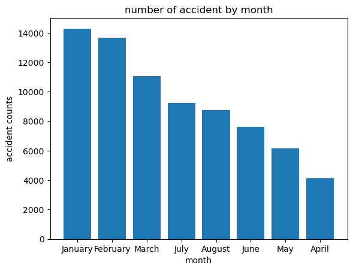

```python
plt.bar(month_accident.index, month_accident.values)
plt.xlabel('month')
plt.ylabel('accident counts')
plt.title('number of accident by month')
```

The accidents reach a lull in Spring months (April, May, June)